# Networks Comparison Tools

Author

Lilou Zulewski

This website features network comparison tools applicable to various types of networks. The comparison tools are functions implemented in R. Initially, you will find the source codes and explanations of how these tools are constructed. Subsequently, a detailed example on gene regulatory networks, which are systems of genes interacting to control gene expression levels, is provided. This example illustrates the application of the comparison tools and offers insights into their practical use.

This tab contains a glossary of key terms for easier understanding.

# Source Code

In this section, you will find the source code for network comparison tools implemented in R that are mainly topological metrics. A step-by-step explanation of each function is available, detailing their construction and functionality. By understanding the underlying code, users can gain a complete overview of how these tools work, enabling them to apply them effectively to different types of networks. This detailed breakdown will also serve as the basis for the following example on gene regulation networks, demonstrating the practical application of these tools.

## Prerequisites

To implement the following metrics, certain R functions are required to format the databases you intend to use.

**Data format**

To apply all the following functions to your dataset, it must contain two columns named `from` and `to`, representing pairs of nodes connected in the graph without any specific orientation.

Firstly, the `SortColumns()` function is designed to standardize the representation of node pairs in a dataset by ensuring they are consistently ordered, irrespective of their original sequence. This function generates a new data frame where each row represents a pair of connected nodes in the network. For each pair, the function sorts the nodes alphabetically or numerically by comparing the values in the `from` and `to` columns. This guarantees a uniform representation of node pairs. Additionally, it eliminates duplicate rows to ensure that each pair is unique, and finally returns the sorted data frame.

**`SortColumns()`**

**Click for more code details.**

```r
# SortColumns() function sorts the pairs of nodes in a dataframe and removes duplicate pairs.
# Parameters:
#   - data: Input dataframe containing gene pairs with columns 'from' and 'to'.
# Returns:
#   - A dataframe with sorted and unique gene pairs.

SortColumns <- function(data) {

  # create a new dataframe with sorted gene pairs
  data_sorted <- data.frame(from = pmin(data$from, data$to), to = pmax(data$from, data$to))

  # remove duplicate rows
  data_sorted <- unique(data_sorted)

  # return the sorted dataframe
  return(data_sorted)

}
```

Next, the `DataframeToGraph()` function converts a dataframe of node pairs into a graph object. First, it sorts the pairs in the input dataframe to ensure consistent representation, then concatenates the `from` and `to` columns into a new dataframe named even, removing any duplicate rows. Finally, it creates a graph object from this dataframe of unique pairs using the `graph_from_data_frame()` function and returns the constructed graph object.

**`DataframeToGraph()`**

**Click for more code details.**

```r
# DataframeToGraph() function converts a dataframe of node pairs into a graph object.
# Parameters:
#   - data: Input dataframe containing node pairs with columns 'from' and 'to'.
# Returns:
#   - An igraph graph object representing the network of node pairs.

DataframeToGraph <- function(data){

  # sort gene pairs in both datasets
  data <- SortColumns(data)

  # concatenate gene pairs into a new dataframe for each dataset
  pairs <- cbind(from = data$from, to = data$to, pairs = paste(data$from, data$to, sep = "_"))

  # remove duplicates in pairs
  unique_pairs <- unique(pairs)

  # load required libraries
  library(tidyr)
  library(igraph)

  # create graph object from dataframe
  graph <- graph_from_data_frame(unique_pairs, directed=FALSE)

  # return the dataframe with the results
  return(graph)

}
```

Now that your database is in the correct format, you can apply the metrics below.

## Graph Metrics

The following metrics have been developed to offer a comprehensive understanding of the similarities and differences between two graphs. These metrics facilitate a detailed analysis of both the structural and functional properties of the graphs.

### Nodes degree distributions

This measure examines the distribution of the number of connections (degrees) of nodes in the graph, providing insight into the connectivity patterns in the graph. The degree distribution of nodes is an essential measure for understanding connectivity in networks. This distribution indicates the number of connections that each node has with other nodes in the network. For example, an asymmetric distribution could indicate the presence of a few highly connected nodes (hubs). Analysis of this distribution allows you to assess the centrality and relative importance of genes within the network.

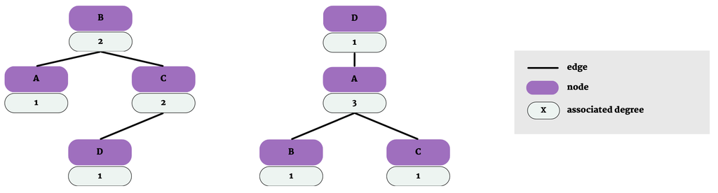

**Figure 1. Schematic example of nodes degree distribution in two networks.** This figure shows two networks characterised by different node degree distributions. Specifically, one network contains two nodes with degree 2 and two nodes with degree 1, while the other network contains one node with degree 3 and three nodes with degree 1. Although the nodes in both examples are identical, the connections they form are very different. For example, node A may be relatively isolated in one network, but may play a central role in the other.

The `DegreeDistribution()` function computes the degree distribution of nodes in a network represented by an input dataframe. It starts by sorting and removing duplicates from pairs of nodes, then collects all the unique nodes present in these pairs. It then traverses these unique nodes to count the number of links associated with each through the columns of the dataframe. The results are then structured into a new dataframe that lists each node with its corresponding degree. Finally, the function ensures that any duplicate entries are removed to ensure that each node is only represented once in the final result.

**`DegreeDistribution()`**

**Click for more code details.**

```r
# DegreeDistribution() function calculates the degree distribution of nodes in a network.
# Parameters:
#   - data: Input dataframe containing node pairs.
# Returns:
#   - A dataframe with unique nodes and their corresponding degrees.

DegreeDistribution <- function(data) {

  # concatenate pairs into a new dataframe and remove duplicates in node pairs
  unique_pairs <- SortColumns(data)

  # initialize a vector to store counts
  all_nodes <- c(unique_pairs[,1], unique_pairs[,2])
  unique_nodes <- unique(all_nodes)
  counts <- numeric(length(unique_nodes))

  # loop through nodes
  for (i in seq_along(unique_nodes)) {
    node <- unique_nodes[i]
    # count the number of associated genes in both columns
    count <- sum(unique_pairs[,1]==node) + sum(unique_pairs[,2]==node)
    counts[i] <- count
  }

  # create a dataframe with the results
  result <- data.frame(node=unique_nodes, degree=counts)

  # remove duplicates
  result <- result[!duplicated(result$node), ]

  # return the results
  return(result)

}
```

The `DegreeDistribution_Comparison()` function makes it easy to compare the degree distributions of nodes between two datasets representing different networks. It starts by loading the `ggplot2` graphing library. It then calculates the degree distributions for each dataset using the `DegreeDistribution()` function and combines these results into a df dataframe. This dataframe is structured to contain information about each unique node and its degree, as well as an indication of which dataset it belongs to (`data1` or `data2`). Using `ggplot2`, the function generates a bar chart showing the degree distributions of the two networks. Each bar is coloured according to the corresponding dataset, allowing an immediate visual comparison of the network structures in terms of the distribution of node connections. This graphical approach helps to quickly identify similarities and differences in the degree distributions between the two networks being analysed.

**`DegreeDistribution_Comparison()`**

**Click for more code details.**

```r
# DegreeDistribution_Comparison() function compares the degree distributions of nodes in two networks and visualizes them using a bar plot.
# Parameters:
#   - data1: Input dataframe containing node pairs for the first network.
#   - data2: Input dataframe containing node pairs for the second network.
# Returns:
#   - A ggplot object visualizing the comparison of degree distributions between the two networks.

DegreeDistribution_Comparison <- function(data1, data2){

  # load the necessary library for the plot
  library(ggplot2)

  # calculate degree counts for each database
  degree_distribution_1 <- DegreeDistribution(data1)
  degree_distribution_2 <- DegreeDistribution(data2)

  # create dataframe for creating comparison plot
  df <- rbind(data.frame(degree_distribution_1, dataset = deparse(substitute(data1))),
              data.frame(degree_distribution_2, dataset = deparse(substitute(data2))))

  # create histogram plot with ggplot
  ggplot(df, aes(x=degree, y=after_stat(count), fill=dataset)) +
    # display a histogram
    geom_histogram(position="dodge", alpha=0.5) +
    # customize legends
    labs(x="Degree",
         y="Number of Nodes",
         title="Comparison of Degree Distributions",
         fill=expression(underline("Dataset"))) +
    # specify legend display
    guides(color="none") +
    # customize text elements
    theme(strip.text.x=element_text(size=8),
          plot.title=element_text(size=12, hjust=0.5, face="bold"),
          legend.title=element_text(size=10))

}
```

### Degree 1 global identity

Degree 1 global identity examines the proportion of nodes sharing identical connectivity to identify similarities between two networks. This metric calculates the percentage of shared edges between two graphs by comparing each pair of nodes to identify those that are shared, thereby assessing the similarity of the relationships between the nodes in the networks under study.

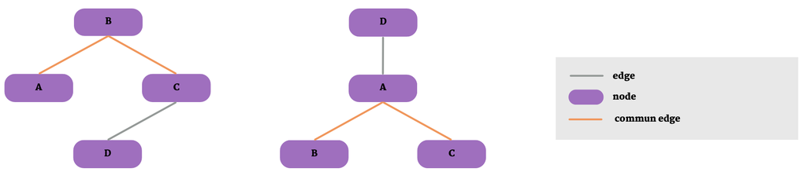

However, a problem arises when the two networks to be compared do not have the same number of edges. To overcome this problem, two different identity percentages need to be considered, each using one of the networks as a reference. The number of edges in network $r$ will be used to calculate the reference identity percentage $p_r$.

The `GlobalIdentity()` function calculates the overall percentage identity of node pairs between two data sets. It starts by checking if one of the datasets is empty. If it is, it returns a list of messages indicating the absence of nodes. It then sorts the pairs in each dataset using the `SortColumns()` function to ensure a consistent representation. The pairs are then concatenated into a single string and duplicates are removed. The function identifies the different pairs present in each data set using `setdiff()`. It then calculates the number of identical edges by subtracting the number of different pairs from the total number of pairs in the other dataset. Finally, it calculates the percentage of identical edges out of the total number of unique pairs in each data set and returns these percentages as a list.

**`GlobalIdentity()`**

**Click for more code details.**

```r
# GlobalIdentity() function calculates the global identity percentage of node pairs between two datasets.
# Parameters:
#   - data1: Input dataframe containing node pairs for the first dataset.
#   - data2: Input dataframe containing node pairs for the second dataset.
# Returns:
#   - A list with the percentage of identical node pairs in each dataset compared to the other.

GlobalIdentity <- function(data1, data2) {

  # check if data1 or data2 is empty
  if (nrow(data1) == 0) {
    return(list(
      identity_percentage_ReferenceData1 = "NO NODE",
      identity_percentage_ReferenceData2 = "/"
    ))
  }
  if (nrow(data2) == 0) {
    return(list(
      identity_percentage_ReferenceData1 = "/",
      identity_percentage_ReferenceData2 = "NO NODE"
    ))
  }

  # sort gene pairs in both datasets
  data1 <- SortColumns(data1)
  data2 <- SortColumns(data2)

  # concatenate gene pairs into a new dataframe for each dataset
  node_pairs_data1 <- cbind(from = data1$from, to = data1$to, pairs = paste(data1$from, data1$to, sep = "_"))
  node_pairs_data2 <- cbind(from = data2$from, to = data2$to, pairs = paste(data2$from, data2$to, sep = "_"))

  # remove duplicates in gene pairs
  unique_pairs_data1 <- unique(node_pairs_data1)
  unique_pairs_data2 <- unique(node_pairs_data2)

  # identify different gene pairs in each dataset
  different_pairs_data1 <- setdiff(unique_pairs_data2[, 3], unique_pairs_data1[, 3])
  different_pairs_data2 <- setdiff(unique_pairs_data1[, 3], unique_pairs_data2[, 3])

  # calculate the number of identical gene pairs in each dataset
  num_identical_pairs_data1 <- length(unique_pairs_data2[, 3]) - length(different_pairs_data1)
  num_identical_pairs_data2 <- length(unique_pairs_data1[, 3]) - length(different_pairs_data2)

  # calculate the percentage of identical gene pairs compared to the total number of unique pairs
  identity_percentage_ReferenceData1 <- (num_identical_pairs_data1 / length(unique_pairs_data1[, 3])) * 100
  identity_percentage_ReferenceData2 <- (num_identical_pairs_data2 / length(unique_pairs_data2[, 3])) * 100

  # construct the final report as a list
  report <- list(
    identity_percentage_ReferenceData1 = identity_percentage_ReferenceData1,
    identity_percentage_ReferenceData2 = identity_percentage_ReferenceData2
  )

  # return the results
  return(report)

}
```

### Percentage of identity on the degree 1 neighbourhood relative to the degree of the nodes

This metric evaluates how the percentage of identity of their first-degree neighbours varies as a function of the degree of the nodes. In other words, this metric determines the percentage of similar edges for a given degree between two graphs.

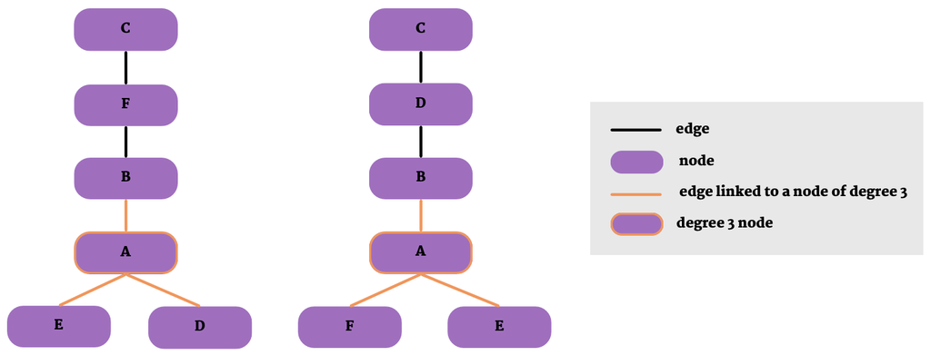

**Figure 3. Schematic example of similar relationships for the same degree.** As an example, this Figure shows the percentage of identity for nodes of degree 3. For instance, gene A is a node of degree 3, i.e. with three edges. Between the two GRNs compared, only two of the three edges are similar, giving a degree 3 identity percentage of 66.67%.

To construct this metric, the same calculation as the previous metric is used for all the degrees present in the two networks, taking into account the possible difference in the number of nodes between the networks being compared. It is important to note that this metric compares the edges connected to different nodes of a given degree, but not the nodes themselves.

The `GlobalIdentity_Degree()` function calculates and compares the degree identity percentages between two node pair data sets. It starts by determining the maximum degree across the two datasets using the `DegreeDistribution()` function. It then initialises a data frame to store the identity percentages for each degree. For each degree, the function extracts lists of matching nodes for each dataset, then selects pairs of matching nodes and eliminates duplicates. Identity percentages are calculated for each degree using the `GlobalIdentity()` function and stored in the dataframe. The function then creates a dataframe for the graph, replacing the `NO NODE` and `/` values with NA values, then changing the NA values to $0$ for easier viewing. The function uses `ggplot2` to create and fit a scatterplot showing the distribution of degrees versus percent identity. Finally, it displays the graph and returns the percent identity dataframe.

**`GlobalIdentity_Degree()`**

**Click for more code details.**

```r
# GlobalIdentity_Degree() function calculates and compares the degree identity percentages between two datasets of node pairs.
# Parameters:
#   - data1: The first dataframe containing node pairs.
#   - data2: The second dataframe containing node pairs.
# Returns:
#   - A dataframe with degrees and their corresponding identity percentages for each dataset.
#   - A scatter plot displaying the degree versus identity percentages.

GlobalIdentity_Degree <- function(data1, data2){

  # determine the maximum degree
  n <- max(DegreeDistribution(data1)$degree, DegreeDistribution(data2)$degree)

  # create a dataframe to store identity percentages
  identity_percentages <- data.frame(degree = 1:n,
                                     ReferenceData1 = numeric(n),
                                     ReferenceData2 = numeric(n))
  # initialize columns for data references
  identity_percentages$ReferenceData1 <- 1
  identity_percentages$ReferenceData2 <- 1

  # iterate over each degree
  for (i in 1:n){
    # extract genes lists for each dataset based on degree
    nodes_list_data1 <- DegreeDistribution(data1)$node[DegreeDistribution(data1)$degree == i]
    nodes_list_data2 <- DegreeDistribution(data2)$node[DegreeDistribution(data2)$degree == i]

    # initialize dataframes to store gene pairs
    all_node_pairs_data1 <- data.frame(from = character(), to = character())
    all_node_pairs_data2 <- data.frame(from = character(), to = character())

    # iterate over genes in each list
    for (node in nodes_list_data1) {
      # select rows where the gene is in the "from" or "to" column
      node_pairs_data1 <- data1[data1$from == node | data1$to == node, c("from", "to")]
      # append gene pairs to all_gene_pairs_data1
      all_node_pairs_data1 <- rbind(all_node_pairs_data1, node_pairs_data1)
    }
    for (node in nodes_list_data2) {
      node_pairs_data2 <- data2[data2$from == node | data2$to == node, c("from", "to")]
      all_node_pairs_data2 <- rbind(all_node_pairs_data2, node_pairs_data2)
    }

    # remove duplicate gene pairs
    all_node_pairs_data1 <- unique(all_node_pairs_data1)
    all_node_pairs_data2 <- unique(all_node_pairs_data2)

    # calculate identity percentages and store in the dataframe
    identity_percentages$ReferenceData1[i] <- GlobalIdentity(all_node_pairs_data1, all_node_pairs_data2)$identity_percentage_ReferenceData1
    identity_percentages$ReferenceData2[i] <- GlobalIdentity(all_node_pairs_data1, all_node_pairs_data2)$identity_percentage_ReferenceData2
  }

  # create a dataframe for the graph
  graph <- data.frame(degree = identity_percentages$degree,
                      percentages = c(identity_percentages$ReferenceData1,
                                      identity_percentages$ReferenceData2),
                      reference = c(rep(deparse(substitute(data1)), length(identity_percentages$ReferenceData1)),
                                    rep(deparse(substitute(data2)), length(identity_percentages$ReferenceData2))),
                      zero_equal = c(identity_percentages$ReferenceData1 == 0 & identity_percentages$ReferenceData2 == 0))

  # remove rows with "NO NODE" or "/" in percentages
  graph$percentages[graph$percentages %in% c("NO NODE", "/")] <- NA

  # remove rows with NA percentages
  graph <- graph[!is.na(graph$percentages), ]

  # assign color based on reference or absence
  graph$color <- ifelse(graph$percentages == 0 & graph$zero_equal, "Both null values", as.character(graph$reference))

  # create the plot
  library(ggplot2)
  plot <- ggplot(graph, aes(x = degree, y = as.numeric(percentages), color = color)) +
    # display a scatterplot
    geom_point() +
    # customize legends
    labs(x = "Degree",
         y = "Identity Percentage",
         title = "Degree of nodes VS Identity percentages",
         color = expression(underline("Reference"))) +
    # specify legend display
    guides(fill = "none") +
    # customize text elements
    theme(strip.text.x = element_text(size = 8),
          plot.title = element_text(size = 12, hjust = 0.5, face = "bold"),
          legend.title = element_text(size = 10))

  # display the plot
  print(plot)

  # return the dataframe with the results
  return(identity_percentages)

}
```

### Identity percentage relative to path length

The last metric studied is the percentage of identity between two inferred networks for different path lengths. It consists of identifying all the paths present in the two networks, then calculating the percentage of identical paths between the two networks as a function of their length. A path of length $n$ comprises $n$ edges and $n+1$ nodes.

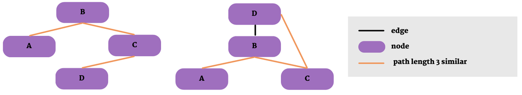

**Figure 4. Schematic example of similar paths for the same length.** For example, this shows the only path of identical length 3 between the two arrays, which includes genes A, B, C and D.

The `GlobalIdentity_Length()` function compares the percentage identity of paths of a given length between two data sets representing networks. It first converts the datasets into graphs, then finds all simple paths in each graph up to a given length. The paths are then filtered to include only those of the specified length. These paths are converted to character identifiers and combined into data frames. The function then identifies pairs of different nodes in each dataset and calculates the number of identical pairs. The percentages of node pair identity out of the total number of unique pairs are calculated and returned as a list.

**`GlobalIdentity_Length()`**

**Click for more code details.**

```r
# GlobalIdentity_Length() function calculates the identity percentages of paths of a given length between two datasets of node pairs.
# Parameters:
#   - data1: The first dataframe containing node pairs.
#   - data2: The second dataframe containing node pairs.
#   - length: The specified length of paths to consider.
# Returns:
#   - A list with identity percentages for each dataset.

GlobalIdentity_Length <- function(data1, data2, length) {

  # convert dataframes to graphs
  graph_data1 <- DataframeToGraph(data1)
  graph_data2 <- DataframeToGraph(data2)

  # initialize variables to store paths
  paths_data1 <- c()
  paths_data2 <- c()

  # find all simple paths in each graph up to a given degree
  l_data1 <- unlist(lapply(V(graph_data1) , function(x) all_simple_paths(graph_data1, from=x, cutoff=length)), recursive = FALSE)
  l_data2 <- unlist(lapply(V(graph_data2) , function(x) all_simple_paths(graph_data2, from=x, cutoff=length)), recursive = FALSE)

  # filter paths to only include those with the specified degree
  l_data1 <- l_data1[lengths(l_data1) == length + 1]
  l_data2 <- l_data2[lengths(l_data2) == length + 1]

  # convert paths to character IDs
  paths_data1 <- lapply(1:length(l_data1), function(x) as_ids(l_data1[[x]]))
  paths_data2 <- lapply(1:length(l_data2), function(x) as_ids(l_data2[[x]]))

  # combine paths into dataframes
  paths_data1 <- do.call(rbind, paths_data1)
  paths_data2 <- do.call(rbind, paths_data2)

  # convert matrices to dataframes
  paths_data1 <- as.data.frame(paths_data1)
  paths_data2 <- as.data.frame(paths_data2)

  # combine paths and create a new column by uniting the paths
  paths_data1 <- data.frame(c(paths_data1, unite(paths_data1, paths, sep="_")))
  paths_data2 <- data.frame(c(paths_data2, unite(paths_data2, paths, sep="_")))

  # identify different gene pairs in each dataset
  different_pairs_data1 <- setdiff(paths_data2[,length+2], paths_data1[,length+2])
  different_pairs_data2 <- setdiff(paths_data1[,length+2], paths_data2[,length+2])

  # calculate the number of identical gene pairs in each dataset
  num_identical_pairs_data1 <- length(paths_data2[,length+1]) - length(different_pairs_data1)
  num_identical_pairs_data2 <- length(paths_data1[,length+1]) - length(different_pairs_data2)

  # calculate the percentage of identical gene pairs compared to the total number of unique pairs
  identity_percentage_ReferenceData1 <- (num_identical_pairs_data1 / length(paths_data1[,length+1])) * 100
  identity_percentage_ReferenceData2 <- (num_identical_pairs_data2 / length(paths_data2[,length+1])) * 100

  # construct the final report as a list
  report <- list(
    identity_percentage_ReferenceData1 = identity_percentage_ReferenceData1,
    identity_percentage_ReferenceData2 = identity_percentage_ReferenceData2
  )

  # return the results
  return(report)

}
```

The `GlobalIdentity_Length_Comparison()` function compares the percentage identity of paths of different lengths between two datasets representing networks. It first converts the datasets into graphs, then finds all simple paths in each graph up to a given maximum length. It then calculates the length of each path and determines the maximum length of the paths in each graph. Using this maximum length, the function initialises a data frame to store the identity percentages. For each path length it calculates the identity degree using the `GlobalIdentity_Length()` function and stores it in the dataframe. Finally, it creates a graph using `ggplot2` to visualise the identity percentages as a function of path length and returns the dataframe containing the results.

**`GlobalIdentity_Length_Comparison()`**

**Click for more code details.**

```r
# GlobalIdentity_Length_Comparison() function compares the identity percentages of paths
# of different lengths between two datasets.
# Parameters:
#   - data1: First input dataframe containing node pairs.
#   - data2: Second input dataframe containing node pairs.
#   - n: Maximum path length to consider.
# Returns:
#   - A dataframe with identity percentages for each path length and a plot comparing these percentages.

GlobalIdentity_Length_Comparison <- function(data1, data2, maxlength) {

  # convert dataframes to graphs
  graph_data1 <- DataframeToGraph(data1)
  graph_data2 <- DataframeToGraph(data2)

  # find all simple paths in each graph up to the specified degree
  l_data1 <- unlist(lapply(V(graph_data1) , function(x) all_simple_paths(graph_data1, from=x, cutoff=maxlength)), recursive = FALSE)
  l_data2 <- unlist(lapply(V(graph_data2) , function(x) all_simple_paths(graph_data2, from=x, cutoff=maxlength)), recursive = FALSE)

  # calculate the length of each path
  lengths_paths_data1 <- sapply(l_data1, length)
  lengths_paths_data2 <- sapply(l_data2, length)

  # find the maximum path length
  maxlength_data1 <- max(lengths_paths_data1)
  maxlength_data2 <- max(lengths_paths_data2)

  # determine the maximum degree to consider
  maxlength <- min(maxlength_data1, maxlength_data2) - 1

  # initialize dataframe to store identity percentages
  graph <- data.frame(identity_percentage_ReferenceData1 = numeric(maxlength),
                      identity_percentage_ReferenceData2 = numeric(maxlength))

  # loop over degrees and calculate identity percentages
  for (i in 1:maxlength){
    # calculate identity percentages only if they are not equal to 0
    if (GlobalIdentity_Length(data1,data2,i)$identity_percentage_ReferenceData1 != 0 ||
        GlobalIdentity_Length(data1,data2,i)$identity_percentage_ReferenceData2 != 0) {
      graph$identity_percentage_ReferenceData1[i] <- GlobalIdentity_Length(data1,data2,i)$identity_percentage_ReferenceData1
      graph$identity_percentage_ReferenceData2[i] <- GlobalIdentity_Length(data1,data2,i)$identity_percentage_ReferenceData2
    }
  }

  # create a dataframe for the graph
  df <- data.frame(length = seq(1,maxlength),
                   percentages = c(graph$identity_percentage_ReferenceData1,
                                   graph$identity_percentage_ReferenceData2),
                   reference = c(rep(deparse(substitute(data1)), length(graph$identity_percentage_ReferenceData1)),
                                 rep(deparse(substitute(data2)), length(graph$identity_percentage_ReferenceData2))))

  # create the plot
  library(ggplot2)
  plot <- ggplot(df, aes(x = length, y = as.numeric(percentages), color = reference)) +
    # display a scatterplot
    geom_point() +
    # customize legends
    labs(x = "Length of Paths",
         y = "Identity Percentage",
         title = "Length of Paths vs Identity Percentages",
         color = expression(underline("Reference"))) +
    # customize scales
    scale_x_continuous(breaks=c(seq(1, maxlength, by = 1))) +
    # customize text elements
    theme(strip.text.x = element_text(size = 8),
          plot.title = element_text(size = 12, hjust = 0.5, face = "bold"),
          legend.title = element_text(size = 10))

  # print the plot
  print(plot)

  # return the dataframe with the results
  return(graph)

}
```

# Sample application

Here’s an example of an application from biology, specifically gene regulatory networks. In these networks, the nodes represent genes, while the edges symbolise the interactions or regulatory actions between these genes.

## Database and inference methods

The networks used as examples in this section were inferred using the DIANE (Cassan, Lèbre, and Martin 2021) and TDCor (Lavenus 2013) methods, which are two different approaches. The dataset used for inference is the LR dataset, which contains microarray analyses of root bending samples taken every three hours from 6 to 54 hours after gravistimulation (Vo et al. 2015). These data contain log2 expression values for all *Arabidopsis thaliana* genes detected on the microarray. Four independent biological replicates were performed at each time point to ensure the robustness and reliability of the data.

Cassan, Océane, Sophie Lèbre, and Antoine Martin. 2021. “Inferring and Analyzing Gene Regulatory Networks from Multi-Factorial Expression Data: A Complete and Interactive Suite.” *BMC Genomics* 22 (387). https://bmcgenomics.biomedcentral.com/articles/10.1186/s12864-021-07659-2.

Lavenus, Julien. 2013. “Analysis of the Gene Regulatory Network Controlling Lateral Root Primordium Initiation and Patterning in *Arabidopsis* Using a Systems Biology Approach.” PhD thesis.

Vo, Ute, Michael H. Wilson1, Kim Kenobi, Peter D. Gould, Fiona C. Robertson, Wendy A. Peerand Mikaël Lucas, Kamal Swarup, et al. 2015. “The Circadian Clock Rephases During Lateral Root Organ Initiation in *Arabidopsis Thaliana*.” *Nature Communications*. https://doi.org/10.1038/ncomms8641.

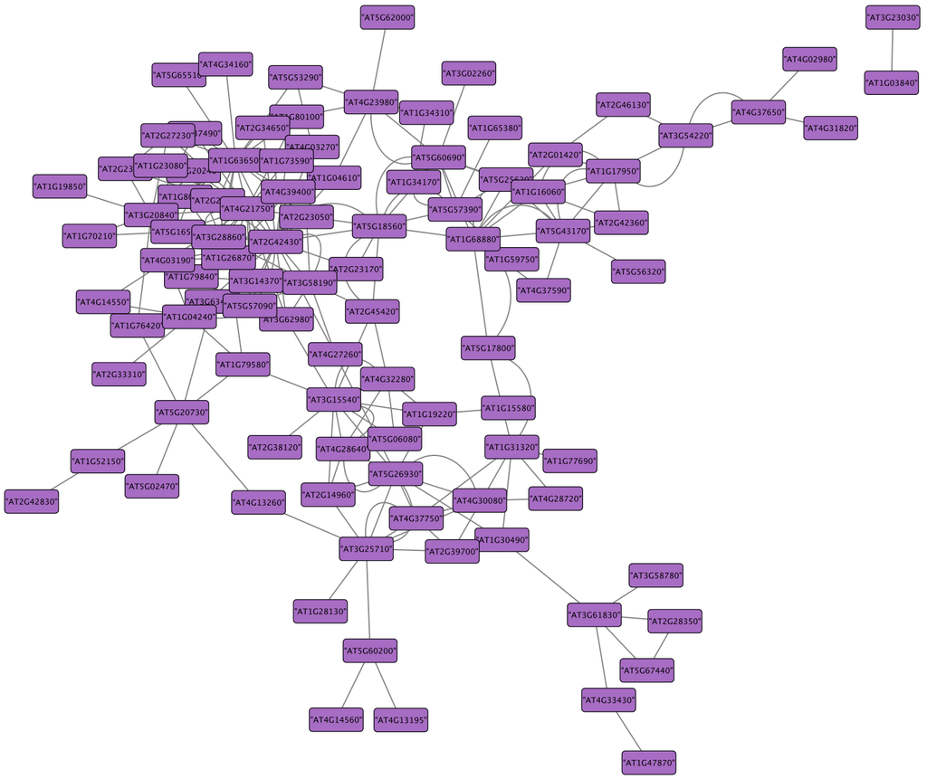

**Figure 5. Gene regulatory network inferred by DIANE on 152 genes selected from the LR database.** This network has 100 nodes and 220 edges.

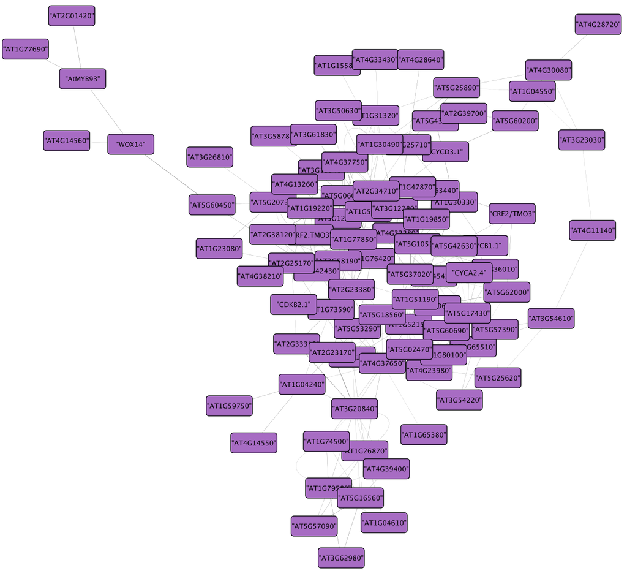

**Figure 6. Gene regulatory network inferred by TDCor on 152 genes selected from the LR database.** This network has 94 nodes and 256 edges.

Those visualisations were made with Cytoscape (Shannon et al. 2003).

Shannon, Paul, Andrew Markiel, Owen Ozier, Nitin S. Baliga, Jonathan T. Wang, Daniel Ramage, Nada Amin, Benno Schwikowski, and Trey Ideker. 2003. “Cytoscape: A Software Environment for Integrated Models of Biomolecular Interaction Networks.” *Cold Spring Harbor Laboratory Press*. http://www.genome.org/cgi/doi/10.1101/gr.1239303.

## Results of the comparison pipeline

To start using the comparison pipeline, we need to import the network data. This can be done using the following command:

**Data import**

```r
DIANE <- read.table(file = "./databases/DIANENetwork.txt", header = TRUE, sep = ";")
TDCor <- read.table(file = "./databases/TDCorNetwork.txt", header = TRUE, sep = ";")
```

This command reads the data from the specified files and stores them in the variables DIANE and TDCor.

To ensure the good importation, you can use this next command to visualize the 6 first rows of your imported database.

**Data preview**

```r
head(DIANE)
```

```
  X.0.109. X.0.446. X.12. X.2.78.    interaction
1       NA       NA    NA      NA interacts with
2       NA       NA    NA      NA interacts with
3       NA       NA    NA      NA interacts with
4       NA       NA    NA      NA interacts with
5       NA       NA    NA      NA interacts with
6       NA       NA    NA      NA interacts with
                                  name selected shared.interaction
1 AT2G28350 (interacts with) AT5G67440    false     interacts with
2 AT1G68880 (interacts with) AT1G16060    false     interacts with
3 AT1G68880 (interacts with) AT5G43170    false     interacts with
4 AT1G68880 (interacts with) AT2G01420    false     interacts with
5 AT1G68880 (interacts with) AT4G37590    false     interacts with
6 AT1G68880 (interacts with) AT5G25620    false     interacts with
                           shared.name      value     weight      from
1 AT2G28350 (interacts with) AT5G67440 0.22662628 0.22662628 AT2G28350
2 AT1G68880 (interacts with) AT1G16060 0.15081864 0.15081864 AT1G68880
3 AT1G68880 (interacts with) AT5G43170 0.11025820 0.11025820 AT1G68880
4 AT1G68880 (interacts with) AT2G01420 0.08848797 0.08848797 AT1G68880
5 AT1G68880 (interacts with) AT4G37590 0.09454279 0.09454279 AT1G68880
6 AT1G68880 (interacts with) AT5G25620 0.11148407 0.11148407 AT1G68880
         to
1 AT5G67440
2 AT1G16060
3 AT5G43170
4 AT2G01420
5 AT4G37590
6 AT5G25620
```

```r
head(TDCor)
```

```
       from V2        to  V4   V5    V6    V7
1 AT4G37750  1 AT1G76420  12 2.78 0.109 0.446
2 AT4G37750 -1 AT5G06080  69 1.74 0.037 0.194
3 AT4G37750  1 AT1G31320  37 1.16 0.027 0.332
4 AT4G37750  1 AT5G12330  61 1.31 0.083 0.039
5 AT4G37750  1 AT2G34710 100 1.07 0.035 0.004
6 AT4G37750  1 AT1G30490   2 1.27 0.101 0.105
```

This will display a preview of the data, helping you verify that the import was successful.

Next, we need to ensure that the columns in both datasets are properly sorted. This is important for consistency in downstream analyses:

**Data formatting**

```r
DIANE <- SortColumns(DIANE)
TDCor <- SortColumns(TDCor)

head(DIANE)
```

```
       from        to
1 AT2G28350 AT5G67440
2 AT1G16060 AT1G68880
3 AT1G68880 AT5G43170
4 AT1G68880 AT2G01420
5 AT1G68880 AT4G37590
6 AT1G68880 AT5G25620
```

```r
head(TDCor)
```

```
       from        to
1 AT1G76420 AT4G37750
2 AT4G37750 AT5G06080
3 AT1G31320 AT4G37750
4 AT4G37750 AT5G12330
5 AT2G34710 AT4G37750
6 AT1G30490 AT4G37750
```

After sorting the columns, you can use the head function again to verify the changes.

To analyze and compare the degree distributions between the two networks, you can use the following function which compares the degree distributions of the nodes in the two networks:

**Degree Distribution**

```r
DegreeDistribution_Comparison(DIANE, TDCor)
```

[figure not shown]

We can observe the degree distribution of nodes in the networks previously inferred by the two studied methods. The x-axis represents the degree of the nodes, which is the number of connections a node has with other nodes in the network. A high value indicates that the node is highly connected and central to many regulations. The y-axis shows the number of nodes with a certain degree. A wider distribution signifies greater variability in the connections between nodes. Overall, this first metric provides an idea of the obvious differences between the two inferred GRNs: the topology of the networks will therefore not be the same depending on the method used.

To calculate the overall similarity between the two networks, use the `GlobalIdentity()` function. This function computes the global identity percentage between the networks, providing a single measure of similarity.

**Global Identity**

```r
GlobalIdentity(DIANE, TDCor)
```

```
$identity_percentage_ReferenceData1
[1] 8.717949

$identity_percentage_ReferenceData2
[1] 6.882591
```

For a more detailed comparison based on node degrees, use the `GlobalIdentity_Degree()` function which calculates the identity percentage for nodes of each degree, giving a degree-specific similarity measure.

**Degree of Nodes as a Function of Identity Percentage**

```r
GlobalIdentity_Degree(DIANE, TDCor)
```

[figure not shown]

```
   degree   ReferenceData1   ReferenceData2
1       1                0                0
2       2                0                0
3       3 1.81818181818182 3.33333333333333
4       4 3.33333333333333 3.07692307692308
5       5                0                0
6       6 11.1111111111111 3.92156862745098
7       7                0                0
8       8             6.25 1.23456790123457
9       9                0                0
10     10                0                0
11     11                0                0
12     12                /          NO NODE
13     13          NO NODE                /
14     14          NO NODE                /
15     15          NO NODE                /
16     16          NO NODE                /
17     17          NO NODE                /
18     18          NO NODE                /
19     19          NO NODE                /
20     20                /          NO NODE
21     21                /          NO NODE
22     22                /          NO NODE
```

For low and high degrees, the nodes identified by the two methods differ significantly. Specifically, the identity percentages are zero for nodes with degrees $1$, $2$, $9$, $10$, and $11$. The identity percentages for medium degrees ($3$ and $4$) show a similar trend, with both methods achieving approximately $3\%$ identity.

This figure allows for a visual comparison of how node degree impacts the identity percentage of GRNs inferred by DIANE and TDCor. Generally, a slight increase in identity percentage with higher node degrees, up to degree $8$, suggests that nodes with more connections are better captured by both methods. According to this metric, both methods appear to be slightly more effective for nodes with medium degrees.

To compare the networks based on the lengths of paths within them, use the `GlobalIdentity_Length_Comparison()` function:

```r
GlobalIdentity_Length_Comparison(DIANE, TDCor,  6)
```

[output not shown]

[output not shown]

# Glossary

**Network.** A network is a structure made up of nodes (or vertices) and edges (or links) that connect these nodes. The nodes represent individual entities, while the edges represent the relationships or interactions between these entities. Networks can be used to model a wide variety of complex systems, such as social networks, communication networks, biological networks (such as gene regulation networks), and many others.

**Gene regulatory network.** A gene regulatory network is a biological model that represents the interactions between genes in a cell. In this network, the nodes represent the genes and the edges represent the regulatory interactions between these genes. The interactions can involve the activation or repression of gene expression, where certain genes (called transcription factors) control the expression of other genes. This type of network is essential for understanding complex biological processes, such as development, stress response and disease, by illustrating how genes regulate each other to orchestrate cellular functions.

**Microarray.** A DNA microarray is a collection of DNA molecules fixed in ordered rows on a small surface, which may be glass, silicon or plastic. This recent biotechnology makes it possible to analyse the level of gene expression (transcripts) in a cell, tissue, organ, organism or even a complex mixture, at a given moment and in a given state compared with a reference sample.

**Gravistimulation.** Exposure of plants to a specific gravitational field.